# Python Datacamp

```python
import numpy as np
import pandas as pd
import matplotlib.pyplot as plt
```

## Logic, Control Flow and Filtering

*Comparison Operators*

`<`, `>`, `>=`, `<=`, `==`, `!=`

*Boolean Operators*

`and`, `or`, `not`

*Conditional Statement*

`if`, `else`, `elif`

**if**

```
if condition :
    expression
```

```python
z = 4
if z % 2 == 0 :   # True
    print ("z is even")
```

```
z is even
```

**else**

```
if condition :
    expression
else :
    expression
```

```python
z = 5
if z % 2 ==0 :  #False
    print ("z is even")
else :
    print ("z is odd")
```

```
z is odd
```

**elif**

```
if condition :
    expression
elif condition :
    expression
else :
    expression
```

```python
z =3
if z % 2 ==0 :
    print("z is divisible by 2")  #False
elif z % 3 ==0 :
    print("z is divisible by 3")  #True
else :
    print("z is neither divisible by 2 nor by 3")
```

```
z is divisible by 3
```

The first condition is false if z is 3, so it goes over to the next condition. The second condition does hold, so the corresponding print statement is executed.

### Driving Right(1)

Remember that `cars` dataset, containing the cars per 1000 people (`cars_per_cap`) and whether people drive right (`drives_right`) for different countries (`country`)? The code that imports this data in CSV format into Python as a DataFrame is included in the script.

In the video, you saw a step-by-step approach to filter observations from a DataFrame based on boolean arrays. Let's start simple and try to find all observations in `cars` where `drives_right` is `True`.

`drives_right` is a boolean column, so you'll have to extract it as a Series and then use this boolean Series to select observations from `cars`.

- Extract the `drives_right` column as a *Pandas Series* and store it as `dr`.
- Use `dr`, a boolean Series, to subset the `cars` DataFrame. Store the resulting selection in `sel`.
- Print `sel`, and assert that `drives_right` is `True` for all observations.

```python
import pandas as pd
import numpy as np
```

```python
# Import cars data
cars = pd.read_csv('CARS.csv', index_col = 0)
cars.head()
```

|  | cars_per_cap | country | drives_right |
| --- | --- | --- | --- |
| US | 809 | United States | True |
| AUS | 731 | Australia | False |
| JAP | 588 | Japan | False |
| IN | 18 | India | False |
| RU | 200 | Russia | True |

```python
# Extract drives_right column as Series: dr
dr = cars["drives_right"]
dr
```

```
US      True
AUS    False
JAP    False
IN     False
RU      True
MOR     True
EG      True
Name: drives_right, dtype: bool
```

```python
# Use dr to subset cars: sel and print sel
sel = cars[dr]
print(sel)
```

```
     cars_per_cap        country  drives_right
US            809  United States          True
RU            200         Russia          True
MOR            70        Morocco          True
EG             45          Egypt          True
```

### Driving Right(2)

The code in the previous example worked fine, but you actually unnecessarily created a new variable `dr`. You can achieve the same result without this intermediate variable. Put the code that computes `dr` straight into the square brackets that select observations from `cars`.

Convert the code to a one-liner that calculates the variable `sel` as before.

```python
# Convert code to a one-liner
sel = cars[cars['drives_right']]
# Print sel
print(sel)
```

```
     cars_per_cap        country  drives_right
US            809  United States          True
RU            200         Russia          True
MOR            70        Morocco          True
EG             45          Egypt          True
```

Nice one! `cars` contains 7 rows or observations, `sel` contains 4; so in the majority of the countries in your dataset, people drive on the right side of the road.

### Cars per capita (1)

Let's stick to the `cars` data some more. This time you want to find out which countries have a high *cars per capita* figure. In other words, in which countries do many people have a car, or maybe multiple cars.

Similar to the previous example, you'll want to build up a boolean Series, that you can then use to subset the `cars` DataFrame to select certain observations. If you want to do this in a one-liner, that's perfectly fine!

- Select the `cars_per_cap` column from `cars` as a Pandas Series and store it as `cpc`.
- Use `cpc` in combination with a comparison operator and `500`. You want to end up with a boolean Series that's `True` if the corresponding country has a `cars_per_cap` of more than `500` and `False` otherwise. Store this boolean Series as `many_cars`.
- Use `many_cars` to subset `cars`, similar to what you did before. Store the result as `car_maniac`.
- Print out `car_maniac` to see if you got it right.

```python
# Import cars data
import pandas as pd
cars = pd.read_csv('cars.csv', index_col = 0)

# Create car_maniac: observations that have a cars_per_cap over 500
cpc = cars["cars_per_cap"]
many_cars = cpc > 500
car_maniac = cars[many_cars]
# Print car_maniac
print(car_maniac)

# alternatively
# print(cars_maniac = cars[cpc > 500])
```

```
     cars_per_cap        country  drives_right
US            809  United States          True
AUS           731      Australia         False
JAP           588          Japan         False
```

Good job! The output shows that the US, Australia and Japan have a `cars_per_cap` of over 500.

### Cars per capita (2)

Remember about `np.logical_and()`, `np.logical_or()` and `np.logical_not()`, the NumPy variants of the `and`, `or` and `not` operators? You can also use them on Pandas Series to do more advanced filtering operations.

Take this example that selects the observations that have a `cars_per_cap` between 10 and 80. Try out these lines of code step by step to see what's happening.

```python
cpc = cars['cars_per_cap']
between = np.logical_and(cpc > 10, cpc < 80)
medium = cars[between]
medium
```

|  | cars_per_cap | country | drives_right |
| --- | --- | --- | --- |
| IN | 18 | India | False |
| MOR | 70 | Morocco | True |
| EG | 45 | Egypt | True |

- Use the code sample provided to create a DataFrame `medium`, that includes all the observations of `cars` that have a `cars_per_cap` between `100` and `500`.
- Print out `medium`.

```python
# Create medium: observations with cars_per_cap between 100 and 500
cpc = cars['cars_per_cap']
between = np.logical_and(cpc > 100, cpc <500)
medium = cars[between]

# Print medium
print(medium)
```

```
    cars_per_cap country  drives_right
RU           200  Russia          True
```

## Loops

### while loop

The while loop executes the code if the condition is true similar as the if-elif-else. However, the while loop will repeat as long as the condition is true.

- while loop = repeated if statement

**while**

```
while condition :
    expression
```

- Example
  - Error starts at 50
  - Divide error by 4 on every run
  - Continue until error no longer > 1

```python
error = 50
while error >1 :
    error = error/4
    print(error)
```

```
12.5
3.125
0.78125
```

### Basic while loop

- Create the variable `offset` with an initial value of `8`.
- Code a `while` loop that keeps running as long as `offset` is not equal to `0`. Inside the while loop:
  - Print out the sentence `"correcting..."`.
  - Next, decrease the value of `offset` by 1. You can do this with `offset = offset - 1`.
  - Finally, still within your loop, print out `offset` so you can see how it changes.

```python
# Initialize offset
offset = 8

# Code the while loop
while offset != 0 :
    print("correcting...")
    offset = offset - 1
    print(offset)
```

### Add conditionals

Fix things by putting an `if-else` statement inside the `while` loop. If your code is still taking too long to run, you probably made a mistake!

- **Inside** the `while` loop, complete the `if-else` statement:
  - If `offset` is greater than zero, you should decrease `offset` by 1.
  - Else, you should increase `offset` by 1.
- If you've coded things correctly, hitting Submit Answer should work this time.

```python
# Initialize offset
offset = -6

# Code the while loop
while offset != 0 :
    print("correcting...")
    if offset > 0 :
      offset = offset -1
    else :
      offset = offset + 1
    print(offset)
```

```
correcting...
-5
correcting...
-4
correcting...
-3
correcting...
-2
correcting...
-1
correcting...
0
```

Good work! The `while` loop is not that often used in Data Science, so let's head over to the `for` loop.

### for loop

for var in seq : expression

- for each variable in sequence, execute expression.

```python
fam = [1.73, 1.68, 1.71, 1.89]
for height in fam :
    print(height)
```

```
1.73
1.68
1.71
1.89
```

```python
# display the index in the list
fam = [1.73, 1.68, 1.71, 1.89]
for index, height in enumerate(fam) :
    print("index " + str(index) + ": " + str(height))
```

```
index 0: 1.73
index 1: 1.68
index 2: 1.71
index 3: 1.89
```

### Loop over a list

As usual, you simply have to indent the code with 4 spaces to tell Python which code should be executed in the `for` loop.

The `areas` variable, containing the area of different rooms in your house, is already defined.

Write a `for` loop that iterates over all elements of the `areas` list and prints out every element separately.

```python
# areas list
areas = [11.25, 18.0, 20.0, 10.75, 9.50]

# Code the for loop
for area in areas :
    print(area)
```

```
11.25
18.0
20.0
10.75
9.5
```

### Indexes and values (1)

Using a `for` loop to iterate over a list only gives you access to every list element in each run, one after the other. If you also want to access the index information, so where the list element you're iterating over is located, you can use `enumerate()`.

- Adapt the `for` loop in the sample code to use `enumerate()` and use two iterator variables.
- Update the `print()` statement so that on each run, a line of the form `"room x: y"` should be printed, where x is the index of the list element and y is the actual list element, i.e. the area. Make sure to print out this exact string, with the correct spacing.

```python
# areas list
areas = [11.25, 18.0, 20.0, 10.75, 9.50]

# Change for loop to use enumerate() and update print()
for index, a in enumerate(areas) :
    print("room " + str(index) + ": " + str(a))
```

```
room 0: 11.25
room 1: 18.0
room 2: 20.0
room 3: 10.75
room 4: 9.5
```

### Indexes and values (2)

For non-programmer folks, `room 0: 11.25` is strange. Wouldn't it be better if the count started at 1?

Adapt the `print()` function in the `for` loop so that the first printout becomes `"room 1: 11.25"`, the second one `"room 2: 18.0"` and so on.

```python
# areas list
areas = [11.25, 18.0, 20.0, 10.75, 9.50]

# Code the for loop
for index, area in enumerate(areas) :
    print("room " + str(index+1) + ": " + str(area))
```

### Loop over list of lists

Remember the `house` variable from the Intro to Python course? Have a look at its definition in the script. It's basically a list of lists, where each sublist contains the name and area of a room in your house.

It's up to you to build a `for` loop from scratch this time!

Write a `for` loop that goes through each sublist of `house` and prints out `the x is y sqm`, where x is the name of the room and y is the area of the room.

```python
# house list of lists
house = [["hallway", 11.25],
         ["kitchen", 18.0],
         ["living room", 20.0],
         ["bedroom", 10.75],
         ["bathroom", 9.50]]

# Build a for loop from scratch
# looping through nested list using multiple
# temporary variables
for x, y in house :
    print("the", x, "is", y, "sqm")
```

```
the hallway is 11.25 sqm
the kitchen is 18.0 sqm
the living room is 20.0 sqm
the bedroom is 10.75 sqm
the bathroom is 9.5 sqm
```

### Loop Data Structures Part 1

- Dictionary
  - for `key, val in my_dict.items() :`
- Numpy array
  - for `val in np.nditer(my_array) :`

### Loop over dictionary

In Python 3, you need the `items()` method to loop over a dictionary:

```python
world = { "afghanistan":30.55,
          "albania":2.77,
          "algeria":39.21 }

for key, value in world.items() :
    print(key + " -- " + str(value))
```

```
afghanistan -- 30.55
albania -- 2.77
algeria -- 39.21
```

Remember the `europe` dictionary that contained the names of some European countries as key and their capitals as corresponding value? Go ahead and write a loop to iterate over it!

Write a `for` loop that goes through each key:value pair of `europe`. On each iteration, `"the capital of x is y"` should be printed out, where x is the key and y is the value of the pair.

```python
# Definition of dictionary
europe = {'spain':'madrid', 'france':'paris', 'germany':'berlin',
          'norway':'oslo', 'italy':'rome', 'poland':'warsaw', 'austria':'vienna' }

# Iterate over europe
for x, y in europe.items() :
    print("the capital of", x, "is", y)
```

### Loop over NumPy array

If you're dealing with a 1D NumPy array, looping over all elements can be as simple as:

```
for x in my_array :
    ...
```

If you're dealing with a 2D NumPy array, it's more complicated. A 2D array is built up of multiple 1D arrays. To explicitly iterate over all separate elements of a multi-dimensional array, you'll need this syntax:

```
for x in np.nditer(my_array) :
    ...
```

### Loop Data Structures Part 2

To iterate over the rows in a pandas dataframe, we store the row labels as lab, and the row data as row.

```python
brics = pd.read_csv("brics.csv", index_col=0)
brics.head()
```

|  | country | capital | area | population |
| --- | --- | --- | --- | --- |
| BR | Brazil | Brasilia | 8.516 | 200.40 |
| RU | Russia | Moscow | 17.100 | 143.50 |
| IN | India | New Delhi | 3.286 | 1252.00 |
| CH | China | Beijing | 9.597 | 1357.00 |
| SA | South Africa | Pretoria | 1.221 | 52.98 |

```python
for lab, row in brics.iterrows() :
    print(lab)
    print(row)
```

```
BR
country         Brazil
capital       Brasilia
area             8.516
population       200.4
Name: BR, dtype: object
RU
country       Russia
capital       Moscow
area            17.1
population     143.5
Name: RU, dtype: object
IN
country           India
capital       New Delhi
area              3.286
population       1252.0
Name: IN, dtype: object
CH
country         China
capital       Beijing
area            9.597
population     1357.0
Name: CH, dtype: object
SA
country       South Africa
capital           Pretoria
area                 1.221
population           52.98
Name: SA, dtype: object
```

In the first iteration above, the `lab` is `BR`, and the row is entire Pandas Series.

Suppose we only want to print out the capital on each iteration:

```python
# print the label and capital together
for lab, row in brics.iterrows() :
    print(lab, ":", row["capital"])
```

```
BR : Brasilia
RU : Moscow
IN : New Delhi
CH : Beijing
SA : Pretoria
```

Now add a new column in this dataframe, called `name_length`, containing the number characters in the country's name.

```python
for lab, row in brics.iterrows() :
    # creating seriers on every iteration
    brics.loc[lab,"name_length"] = len(row["country"])
print(brics)
```

```
         country    capital    area  population  name_length
BR        Brazil   Brasilia   8.516      200.40          6.0
RU        Russia     Moscow  17.100      143.50          6.0
IN         India  New Delhi   3.286     1252.00          5.0
CH         China    Beijing   9.597     1357.00          5.0
SA  South Africa   Pretoria   1.221       52.98         12.0
```

A new column called `name_length` was created in the dataframe with the length of country names.

But this is not efficient, because you are creating a series object on every iteration.

A better way to calculate the entire dataframe column by applying a function on a particular column in an element-wise fasion is to use **apply()**.

```python
brics["name_length"] = brics["country"].apply(len)
print(brics)
```

```
         country    capital    area  population  name_length
BR        Brazil   Brasilia   8.516      200.40            6
RU        Russia     Moscow  17.100      143.50            6
IN         India  New Delhi   3.286     1252.00            5
CH         China    Beijing   9.597     1357.00            5
SA  South Africa   Pretoria   1.221       52.98           12
```

Basicly, you are selecting the country column from the `brics` dataframe and then apply the `len()` function on `country` column. Apply calls the `len()` function with each country name as input and produces a new array, that you can easily store as a new column called `name_length`.

### Loop over DataFrame (1)

Iterating over a Pandas DataFrame is typically done with the `iterrows()` method. Used in a `for` loop, every observation is iterated over and on every iteration the row label and actual row contents are available:

```
`for lab, row in brics.iterrows() :
          ...`
```

In this and the following exercises you will be working on the `cars` DataFrame. It contains information on the cars per capita and whether people drive right or left for seven countries in the world.

Write a `for` loop that iterates over the rows of `cars` and on each iteration perform two `print()` calls: one to print out the row label and one to print out all of the rows contents.

```python
# import dataset
cars = pd.read_csv('CARS.csv', index_col = 0)
cars.head()
```

|  | cars_per_cap | country | drives_right |
| --- | --- | --- | --- |
| US | 809 | United States | True |
| AUS | 731 | Australia | False |
| JAP | 588 | Japan | False |
| IN | 18 | India | False |
| RU | 200 | Russia | True |

```python
# Iterate over rows of cars
for lab, row in cars.iterrows() :
    print(lab)
    print(row)
```

```
US
cars_per_cap              809
country         United States
drives_right             True
Name: US, dtype: object
AUS
cars_per_cap          731
country         Australia
drives_right        False
Name: AUS, dtype: object
JAP
cars_per_cap      588
country         Japan
drives_right    False
Name: JAP, dtype: object
IN
cars_per_cap       18
country         India
drives_right    False
Name: IN, dtype: object
RU
cars_per_cap       200
country         Russia
drives_right      True
Name: RU, dtype: object
MOR
cars_per_cap         70
country         Morocco
drives_right       True
Name: MOR, dtype: object
EG
cars_per_cap       45
country         Egypt
drives_right     True
Name: EG, dtype: object
```

### Loop over DataFrame (2)

The row data that's generated by `iterrow()` on every run is a Pandas Series. This format is not very convenient to print out. Luckily, you can easily select variables from the Pandas Series using square brackets:

```
for lab, row in brics.iterrows() :
             print(row['country'])
```

- Using the iterators `lab` and `row`, adapt the code in the for loop such that the first iteration prints out `"US: 809"`, the second iteration `"AUS: 731"`, and so on.
- The output should be in the form `"country: cars_per_cap"`. Make sure to print out this exact string (with the correct spacing).

*You can use `str()` to convert your integer data to a string so that you can print it in conjunction with the country label.*

```python
# Adapt for loop
for lab, row in cars.iterrows() :
    print(lab + ": " + str(row['cars_per_cap']))
```

```
US: 809
AUS: 731
JAP: 588
IN: 18
RU: 200
MOR: 70
EG: 45
```

### Add column (1)

In the video, Hugo showed you how to add the length of the country names of the `brics` DataFrame in a new column:

```
  `for lab, row in brics.iterrows() :
         brics.loc[lab, "name_length"] = len(row["country"])`
```

- Use a `for` loop to add a new column, named `COUNTRY`, that contains a uppercase version of the country names in the `"country"` column. You can use the string method `upper()` for this.
- To see if your code worked, print out `cars`. Don't indent this code, so that it's not part of the `for` loop.

```python
# Code for loop that adds COUNTRY column
for lab, row in cars.iterrows() :
    cars.loc[lab, 'COUNTRY'] = row['country'].upper()
# Print cars
print(cars)
```

```
     cars_per_cap        country  drives_right        COUNTRY
US            809  United States          True  UNITED STATES
AUS           731      Australia         False      AUSTRALIA
JAP           588          Japan         False          JAPAN
IN             18          India         False          INDIA
RU            200         Russia          True         RUSSIA
MOR            70        Morocco          True        MOROCCO
EG             45          Egypt          True          EGYPT
```

### Add column (2)

Using `iterrows()` to iterate over every observation of a Pandas DataFrame is easy to understand, but not very efficient. On every iteration, you're creating a new Pandas Series.

If you want to add a column to a DataFrame by calling a function on another column, the `iterrows()` method in combination with a `for` loop is not the preferred way to go. Instead, you'll want to use `apply()`.

We can do a similar thing to call the `upper()` method on every name in the `country` column. However, `upper()` is a method, so we'll need a slightly different approach:

- Replace the `for` loop with a one-liner that uses `.apply(str.upper)`. The call should give the same result: a column `COUNTRY` should be added to `cars`, containing an uppercase version of the country names.
- As usual, print out `cars` to see the fruits of your hard labor.

```python
# Use .apply(str.upper)
cars['COUNTRY'] = cars['country'].apply(str.upper)
# print data
print(cars)
```

```
     cars_per_cap        country  drives_right        COUNTRY
US            809  United States          True  UNITED STATES
AUS           731      Australia         False      AUSTRALIA
JAP           588          Japan         False          JAPAN
IN             18          India         False          INDIA
RU            200         Russia          True         RUSSIA
MOR            70        Morocco          True        MOROCCO
EG             45          Egypt          True          EGYPT
```

## Case Study: Hacker Statistics

### Random float

Randomness has many uses in science, art, statistics, cryptography, gaming, gambling, and other fields. You're going to use randomness to simulate a game.

All the functionality you need is contained in the `random` package, a sub-package of `numpy`. In this exercise, you'll be using two functions from this package:

- `seed()`: sets the random seed, so that your results are reproducible between simulations. As an argument, it takes an integer of your choosing. If you call the function, no output will be generated.
- `rand()`: if you don't specify any arguments, it generates a random float between zero and one.

```python
# Set the seed
np.random.seed(123)

# Generate and print random float
print(np.random.rand())
```

```
0.6964691855978616
```

### Roll the dice

In the previous exercise, you used `rand()`, that generates a random float between 0 and 1.

As Hugo explained in the video you can just as well use `randint()`, also a function of the `random` package, to generate integers randomly. The following call generates the integer 4, 5, 6 or 7 randomly. **8 is not included**.

```python
import numpy as np
np.random.randint(4, 8)
```

- Use `randint()` with the appropriate arguments to randomly generate the integer 1, 2, 3, 4, 5 or 6. This simulates a dice. Print it out.
- Repeat the outcome to see if the second throw is different. Again, print out the result.

```python
# set seed
np.random.seed(123)

# Use randint() to simulate a dice
print(np.random.randint(1,7))

# Use randint() again
print(np.random.randint(1,7))
```

```
6
3
```

### Determine your next move

In the Empire State Building bet, your next move depends on the number of eyes you throw with the dice. We can perfectly code this with an `if-elif-else` construct!

The sample code assumes that you're currently at step 50. Can you fill in the missing pieces to finish the script? `numpy` is already imported as `np` and the seed has been set to `123`, so you don't have to worry about that anymore.

- Roll the dice. Use `randint()` to create the variable `dice`.
- Finish the `if-elif-else`:
  - If `dice` is 1 or 2, you go one step down.
  - if `dice` is 3, 4 or 5, you go one step up.
  - Else, you throw the dice again. The number of eyes is the number of steps you go up.
  - Print out `dice` and `step`. Given the value of `dice`, was `step` updated correctly?

```python
# set seed
np.random.seed(123)

# Starting step
step = 50

# Roll the dice
dice = np.random.randint(1,7)

# Finish the control construct
if dice <= 2 :
    step = step - 1
elif dice <= 5 :
    step = step + 1
else :
    step = step + np.random.randint(1,7)

# Print out dice and step
print(dice)
print(step)
```

```
6
53
```

Cool! You threw a 6, so the code for the `else` statement was executed. You threw again, and apparently you threw 3, causing you to take three steps up: you're currently at step 53.

### Heads or Tails

```python
np.random.seed(123)
outcomes = []
for x in range(10) :
    coin = np.random.randint(0,2) # generate random integer 0(heads) or 1(tails).
    if coin == 0 :
        outcomes.append("heads")
    else :
        outcomes.append("tails")
print(outcomes)
```

```
['heads', 'tails', 'heads', 'heads', 'heads', 'heads', 'heads', 'tails', 'tails', 'heads']
```

The code keeps the outcome for playing a game of head or tail 10 times, with the random number generator.

After importing numpy and setting a seed for random code generator, we initialize an empty list `outcomes`.

Next we build a `for` loop that should run 10 times with `range()` function, that generates a list of numbers that you can use to iterate over. Inside this `for` loop, we generate a random integer coin that either 0 (heads) or 1 (tails). If coin is 0, we append the string `"heads"` to the list. Else, we append the string `"tails"` to the list.

Finally, we print the outcomes list we've build up in this 10 iterations.

```python
# random walk
np.random.seed(123)
tails = [0]
for x in range(10) :
    coin = np.random.randint(0,2)
    tails.append(tails[x] + coin)
print(tails)
```

```
[0, 0, 1, 1, 1, 1, 1, 1, 2, 3, 3]
```

In this case, we create a list `tails` that already contains the number 0, because at the start, we haven't thrown any tails. Then start to run a `for` loop 10 times, using the `rang()` function. In there, generate a random number either 0 or 1. If coin is 0, so heads, the number of tails you've thrown shouldn't change. If 1 is generated, the number of tails should be incremented with 1.

Finally, the `tails` list tells you how often tails was thrown. The numbers in the `tails` list are incremented by one each time you threw tails. This is exactly how a bunch of random steps are converted in to a random walk.

### The Next Step

Before, you have already written Python code that determines the next step based on the previous step. Now it's time to put this code inside a `for` loop so that we can simulate a random walk.

- Make a list `random_walk` that contains the first step, which is the integer 0.
- Finish the `for` loop:
  - The loop should run `100` times.
  - On each iteration, set `step` equal to the last element in the `random_walk` list. You can use the index `-1` for this.
  - Next, let the `if-elif-else` construct update `step` for you.
- The code that appends `step` to `random_walk` is already coded.
- Print out `random_walk`.

```python
# NumPy is imported, seed is set
np.random.seed(123)
# Initialize random_walk
random_walk = [0]

# Complete the loop
for x in range(100) :
    # Set step: last element in random_walk
    step = random_walk[-1]

    # Roll the dice
    dice = np.random.randint(1,7)

    # Determine next step
    if dice <= 2:
        step = step - 1
    elif dice <= 5:
        step = step + 1
    else:
        step = step + np.random.randint(1,7)

    # append next_step to random_walk
    random_walk.append(step)

# Print random_walk
print(random_walk)
```

```
[0, 3, 4, 5, 4, 5, 6, 7, 6, 5, 4, 3, 2, 1, 0, -1, 0, 5, 4, 3, 4, 3, 4, 5, 6, 7, 8, 7, 8, 7, 8, 9, 10, 11, 10, 14, 15, 14, 15, 14, 15, 16, 17, 18, 19, 20, 21, 24, 25, 26, 27, 32, 33, 37, 38, 37, 38, 39, 38, 39, 40, 42, 43, 44, 43, 42, 43, 44, 43, 42, 43, 44, 46, 45, 44, 45, 44, 45, 46, 47, 49, 48, 49…
```

There's still something wrong: the level at index 15 is negative!

### How low can you go?

Things are shaping up nicely! You already have code that calculates your location in the Empire State Building after 100 dice throws. However, there's something we haven't thought about - you can't go below 0!

A typical way to solve problems like this is by using `max()`. If you pass `max()` two arguments, the biggest one gets returned. For example, to make sure that a variable `x` never goes below `10` when you decrease it, you can use:

`x = max(10, x - 1)`

- Use `max()` in a similar way to make sure that `step` doesn't go below zero if `dice <= 2`.

```python
# NumPy is imported, seed is set
np.random.seed(123)
# Initialize random_walk
random_walk = [0]

for x in range(100) :
    step = random_walk[-1]
    dice = np.random.randint(1,7)

    if dice <= 2:
        # Replace below: use max to make sure step can't go below 0
        step = max(0, step - 1)
    elif dice <= 5:
        step = step + 1
    else:
        step = step + np.random.randint(1,7)

    random_walk.append(step)

print(random_walk)
```

```
[0, 3, 4, 5, 4, 5, 6, 7, 6, 5, 4, 3, 2, 1, 0, 0, 1, 6, 5, 4, 5, 4, 5, 6, 7, 8, 9, 8, 9, 8, 9, 10, 11, 12, 11, 15, 16, 15, 16, 15, 16, 17, 18, 19, 20, 21, 22, 25, 26, 27, 28, 33, 34, 38, 39, 38, 39, 40, 39, 40, 41, 43, 44, 45, 44, 43, 44, 45, 44, 43, 44, 45, 47, 46, 45, 46, 45, 46, 47, 48, 50, 49, 50…
```

If you look closely at the output, you'll see that around index 15 the step stays at 0. You're not going below zero anymore. Great!

### Visualize the walk

Let's visualize this random walk! Remember how you could use `matplotlib` to build a line plot?

```
import matplotlib.pyplot as plt
plt.plot(x, y)
plt.show()
```

The first list you pass is mapped onto the `x` axis and the second list is mapped onto the `y` axis.

If you pass only one argument, Python will know what to do and will use the index of the list to map onto the `x` axis, and the values in the list onto the `y` axis.

Add some lines of code after the for loop:

- Import `matplotlib.pyplot` as `plt`.
- Use `plt.plot()` to plot `random_walk`.
- Finish off with `plt.show()` to actually display the plot.

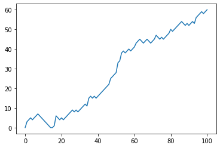

```python
# matplotlib.pyplt is already imported
# Plot random_walk
plt.plot(random_walk)

# Show the plot
plt.show()
```

### Distribution

To find the distribution of a random walk, we start by setting a random seed and the create an empty list called `final_tails`. This list will contain the number of tails you end up with if you play this game of tossing a coin 10 times over and over again.

The outcome of `final_tails` contains numbers between 0 and 10. Each number is the number of tails that were thrown in a game of 10 tosses. All these values represent a distribution that we can visualize it.

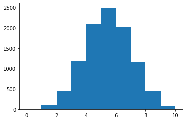

```python
np.random.seed(123)
final_tails = []
for x in range(10000) : # by increasing the number of simulation, the distribution starts to convert to theoretical normal distribution
    tails = [0]
    for x in range(10) :
        coin = np.random.randint(0,2)
        tails.append(tails[x]+coin)
    final_tails.append(tails[-1])
plt.hist(final_tails, bins=10)
plt.show()
```

### Simulate multiple walks

A single random walk is one thing, but that doesn't tell you if you have a good chance at winning the bet.

To get an idea about how big your chances are of reaching 60 steps, you can repeatedly simulate the random walk and collect the results. That's exactly what you'll do in this exercise.

The sample code already sets you off in the right direction. Another `for` loop is wrapped around the code you already wrote. It's up to you to add some bits and pieces to make sure all of the results are recorded correctly.

- Fill in the specification of the `for` loop so that the random walk is simulated 10 times.
- After the `random_walk` array is entirely populated, append the array to the `all_walks` list.
- Finally, after the top-level `for` loop, print out `all_walks`.

```python
np.random.seed(123)
# Initialize all_walks (don't change this line)
all_walks = []

# Simulate random walk 10 times
for i in range(10) :

    # Code from before
    random_walk = [0]
    for x in range(100) :
        step = random_walk[-1]
        dice = np.random.randint(1,7)

        if dice <= 2:
            step = max(0, step - 1)
        elif dice <= 5:
            step = step + 1
        else:
            step = step + np.random.randint(1,7)
        random_walk.append(step)

    # Append random_walk to all_walks
    all_walks.append(random_walk)

# Print all_walks
print(all_walks)
```

```
[[0, 3, 4, 5, 4, 5, 6, 7, 6, 5, 4, 3, 2, 1, 0, 0, 1, 6, 5, 4, 5, 4, 5, 6, 7, 8, 9, 8, 9, 8, 9, 10, 11, 12, 11, 15, 16, 15, 16, 15, 16, 17, 18, 19, 20, 21, 22, 25, 26, 27, 28, 33, 34, 38, 39, 38, 39, 40, 39, 40, 41, 43, 44, 45, 44, 43, 44, 45, 44, 43, 44, 45, 47, 46, 45, 46, 45, 46, 47, 48, 50, 49, 5…
```

### Visualize all walks

`all_walks` is a list of lists: every sub-list represents a single random walk. If you convert this list of lists to a NumPy array, you can start making interesting plots! `matplotlib.pyplot` is already imported as `plt`.

The nested `for` loop is already coded for you - don't worry about it. For now, focus on the code that comes after this `for` loop.

- Use `np.array()` to convert `all_walks` to a NumPy array, `np_aw`.
- Try to use `plt.plot()` on `np_aw`. Also include `plt.show()`. Does it work out of the box?
- Transpose `np_aw` by calling `np.transpose()` on `np_aw`. Call the result `np_aw_t`. Now every row in `np_all_walks` represents the position after 1 throw for the 10 random walks.
- Use `plt.plot()` to plot `np_aw_t`; also include a `plt.show()`. Does it look better this time?

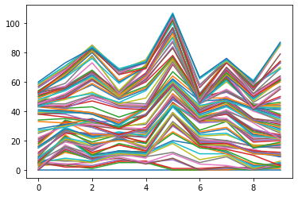

```python
np.random.seed(123)
# initialize and populate all_walks
all_walks = []
for i in range(10) :
    random_walk = [0]
    for x in range(100) :
        step = random_walk[-1]
        dice = np.random.randint(1,7)
        if dice <= 2:
            step = max(0, step - 1)
        elif dice <= 5:
            step = step + 1
        else:
            step = step + np.random.randint(1,7)
        random_walk.append(step)
    all_walks.append(random_walk)

# Convert all_walks to NumPy array: np_aw
np_aw = np.array(all_walks)

# Plot np_aw and show
plt.plot(np_aw)
plt.show()

# Clear the figure
# plt.clf()
```

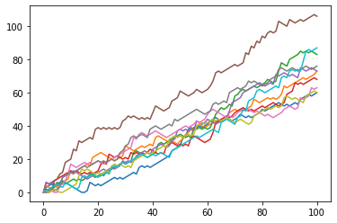

```python
# Transpose np_aw:
np_aw_t = np.transpose(np_aw)

# Plot np_aw_t and show
plt.plot(np_aw_t)
plt.show()
```

You can clearly see how the different simulations of the random walk went. Transposing the 2D NumPy array was crucial; otherwise Python misunderstood.

### Implement clumsiness

With this neatly written code of yours, changing the number of times the random walk should be simulated is super-easy. You simply update the `range()` function in the top-level `for` loop.

There's still something we forgot! You're a bit clumsy and you have a 0.1% chance of falling down. That calls for another random number generation. Basically, you can generate a random float between 0 and 1. If this value is less than or equal to 0.001, you should reset step to 0.

- Change the `range()` function so that the simulation is performed 250 times.
- Finish the `if` condition so that `step` is set to 0 if a random float is less or equal to 0.001. Use `np.random.rand()`.

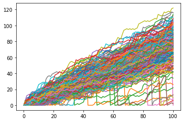

```python
np.random.seed(123)

# Simulate random walk 250 times
all_walks = []
for i in range(250) :
    random_walk = [0]
    for x in range(100) :
        step = random_walk[-1]
        dice = np.random.randint(1,7)
        if dice <= 2:
            step = max(0, step - 1)
        elif dice <= 5:
            step = step + 1
        else:
            step = step + np.random.randint(1,7)

        # Implement clumsiness
        if np.random.rand() <= 0.001 :
            step = 0

        random_walk.append(step)
    all_walks.append(random_walk)

# Create and plot np_aw_t
np_aw_t = np.transpose(np.array(all_walks))
plt.plot(np_aw_t)
plt.show()
```

### Plot the distribution

All these fancy visualizations have put us on a sidetrack. We still have to solve the million-dollar problem: What are the odds that you'll reach 60 steps high on the Empire State Building?

Basically, you want to know about the end points of all the random walks you've simulated. These end points have a certain distribution that you can visualize with a histogram.

Note that if your code is taking too long to run, you might be plotting a histogram of the wrong data!

- To make sure we've got enough simulations, go crazy. Simulate the random walk 500 times.
- From `np_aw_t`, select the last row. This contains the endpoint of all 500 random walks you've simulated. Store this NumPy array as `ends`.
- Use `plt.hist()` to build a histogram of `ends`. Don't forget `plt.show()` to display the plot.

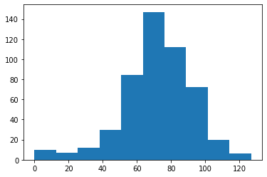

```python
# numpy and matplotlib imported, seed set
np.random.seed(123)
# Simulate random walk 500 times
all_walks = []
for i in range(500) :
    random_walk = [0]
    for x in range(100) :
        step = random_walk[-1]
        dice = np.random.randint(1,7)
        if dice <= 2:
            step = max(0, step - 1)
        elif dice <= 5:
            step = step + 1
        else:
            step = step + np.random.randint(1,7)
        if np.random.rand() <= 0.001 :
            step = 0
        random_walk.append(step)
    all_walks.append(random_walk)

# Create and plot np_aw_t
np_aw_t = np.transpose(np.array(all_walks))

# Select last row from np_aw_t: ends
ends = np_aw_t[-1,:] # last row from numpy array

# Plot histogram of ends, display plot
plt.hist(ends)
plt.show()
```

### Calculate the odds

The histogram of the previous exercise was created from a NumPy array `ends`, that contains 500 integers. Each integer represents the end point of a random walk. To calculate the chance that this end point is greater than or equal to 60, you can count the number of integers in `ends` that are greater than or equal to 60 and divide that number by 500, the total number of simulations.

Well then, what's the estimated chance that you'll reach 60 steps high if you play this Empire State Building game? The `ends` array is everything you need; it's available in your Python session so you can make calculations in the IPython Shell.

```python
# calculate the probability that the end point >= 60 in 500 simulations
end_point = np.count_nonzero(ends >= 60)
print(end_point/500)
```

```
0.784
```

So there are 78.4% chance you'll reach 60 steps high.